# Queensland Commercial Line Fishery: Catch & Effort (1990–2024)

Samay Rao

26 Sep 2025

## Inroduction

This short report explores catch and effort in Queensland’s Commercial Line Fishery using data sourced from the QFISH open data portal (Queensland Department of Agriculture and Fisheries). The dataset contains yearly catch and effort summaries by Species Group, Species, and Region, with three key metrics recorded each year:

Licences (number of active licences)

Days (fishing days)

Tonnes (landed catch, metric tonnes)

# Data source

Portal: QFISH — Commercial Line Fishery (publicly available).

Download method: I used the table builder to place Species Group and Region as dimensions, CalendarYear as columns, and included the measures Licences, Days, and Tonnes.

Export: CSV for analysis in R.

# Manual cleaning (Excel) — what I changed and why

The QFISH export is a wide table with multi-row headers, which is convenient for browsing but awkward for R. Because my first attempts to pivot directly in R ran into header and naming issues, I did a light, one-time manual tidy in Excel:

Removed extra header rows (e.g., the separate “CalendarYear” line and any merged header cells), leaving a single header row.

Ensured the first three columns are SpeciesGroup, Species, Region.

Flattened year/metric headers so each year has three columns named like: Licences_1990, Days_1990, Tonnes_1990, … (one row per species/region).

Deleted “Total” rows (e.g., rows ending in “Total”) and the very last Grand Total row to avoid double-counting.

Dropped trailing total columns, if present (e.g., totals across all years at the far right).

Replaced obvious text NAs (“N/A”, blanks) with empty cells, kept thousands separators (e.g., 1,112.42).

Saved as UTF-8 CSV: comercial line fishing dataset.csv.

Why keep the file wide? The R script below pivots to tidy long format in a reproducible way. The manual steps above only normalize messy headers once so R can reliably parse and pivot every time.

# Questions we address

1. How has total catch (Tonnes) changed statewide over time?
2. Which species groups dominate the catch, and how have they trended?
3. How do regions differ through time?

# Methods (summary)

Import CSV with readr::read_csv() (preserving numeric punctuation).

Standardize names (janitor::clean_names()), pivot to long format using tidyr::pivot_longer().

Aggregate with dplyr::summarise() and visualize with ggplot2.

Export publication-quality PNGs for the e-portfolio.

## Loading all the packages required

```r
# Packages
library(tidyverse)   # dplyr, ggplot2, tidyr, readr, etc.
library(stringr)
library(scales)
# A small helper for a clean ggplot look
theme_set(theme_minimal(base_size = 12))

# Where to save figures
plots_dir <- "plots"
if (!dir.exists(plots_dir)) dir.create(plots_dir)
```

## Importing the dataset

```r
# NOTE: the CSV uses numbers like 1,112.42; tell readr that "," is a thousands separator
raw <- readr::read_csv(
  "comericial line fishing dataset.csv",
  locale = readr::locale(grouping_mark = ","),
  na = c("NA", "", "N/A")
)
glimpse(raw)
```

```
## Rows: 2,530
## Columns: 108
## $ SpeciesGroup  <chr> "Barramundi", "Barramundi", "Barramundi", "Barramundi", …
## $ Species       <chr> "Barramundi", "Barramundi", "Barramundi", "Barramundi", …
## $ Region        <chr> "East coast", "Great barrier reef marine park", "Mapston…
## $ Licences_1990 <dbl> NA, NA, NA, NA, NA, NA, NA, NA, NA, NA, NA, NA, NA, NA, …
## $ Days_1990     <dbl> NA, NA, NA, NA, NA, NA, NA, NA, NA, NA, NA, NA, NA, NA, …
## $ Tonnes_1990   <dbl> NA, NA, NA, NA, NA, NA, NA, NA, NA, NA, NA, NA, NA, NA, …
## $ Licences_1991 <dbl> NA, NA, NA, NA, NA, NA, NA, NA, NA, NA, NA, NA, NA, NA, …
## $ Days_1991     <dbl> NA, NA, NA, NA, NA, NA, NA, NA, NA, NA, NA, NA, NA, NA, …
## $ Tonnes_1991   <dbl> NA, NA, NA, NA, NA, NA, NA, NA, NA, NA, NA, NA, NA, NA, …
## $ Licences_1992 <dbl> NA, NA, NA, NA, NA, NA, NA, NA, NA, NA, NA, NA, NA, NA, …
## $ Days_1992     <dbl> NA, NA, NA, NA, NA, NA, NA, NA, NA, NA, NA, NA, NA, NA, …
## $ Tonnes_1992   <dbl> NA, NA, NA, NA, NA, NA, NA, NA, NA, NA, NA, NA, NA, NA, …
## $ Licences_1993 <dbl> NA, NA, NA, NA, NA, NA, NA, NA, NA, NA, NA, NA, NA, NA, …
```

[output cut: 95 more lines]

## Tidying the datset to long format

The wide file has three metrics repeated for each year: Licences, Days, Tonnes. We’ll pivot columns that match Metric_YYYY into tidy columns: Metric, Year, Value.

```r
## tidying the dataset to long format
tidy <- raw %>%
  pivot_longer(
    cols = matches("(?i)^(licen[cs]es|days|tonnes)_\\d{4}$"),
    names_to  = c("Metric", "Year"),
    names_sep = "_",
    values_to = "Value"
  ) %>%
  mutate(
    Metric = stringr::str_to_title(Metric),  # Licences/Days/Tonnes
    Year   = as.integer(Year),
    SpeciesGroup = dplyr::coalesce(SpeciesGroup, "Unknown"),
    Species      = dplyr::coalesce(Species, "Unspecified"),
    Region       = dplyr::coalesce(Region,  "Unspecified")
  )
```

## Creating a simple statewide time-series

we are creating a plot to calcualte the total Tonnes landed across all regions & species by year.

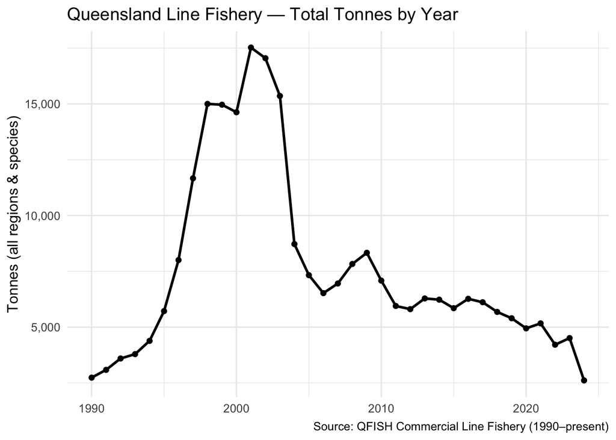

```r
state_tonnes <- tidy %>%
  filter(Metric == "Tonnes") %>%
  group_by(Year) %>%
  summarise(Tonnes = sum(Value, na.rm = TRUE), .groups = "drop")

p_state <- ggplot(state_tonnes, aes(Year, Tonnes)) +
  geom_line(linewidth = 1) +
  geom_point(size = 1.7) +
  scale_y_continuous(labels = label_number(big.mark = ",")) +
  labs(title = "Queensland Line Fishery — Total Tonnes by Year",
       y = "Tonnes (all regions & species)",
       x = NULL,
       caption = "Source: QFISH Commercial Line Fishery (1990–present)")

p_state
```

```r
# Save for your e-portfolio
ggsave(file.path(plots_dir, "statewide_tonnes_by_year.png"), p_state, width = 9, height = 5, dpi = 300)
```

Figure 1. Statewide commercial line fishery catch (tonnes) by year (1990–2024). Values are aggregated across all regions and species. Totals were computed with missing values kept as NA and excluded from sums (na.rm = TRUE). Overall, catch peaks in the late 1990s/early 2000s and then shows a longer-term decline with smaller rebounds in later years. Source: QFISH Commercial Line Fishery.

## Top Species group- Tonnes over time(Faceted)

we are Picking the top 6 SpeciesGroup by total Tonnes and showing a faceted time-series.

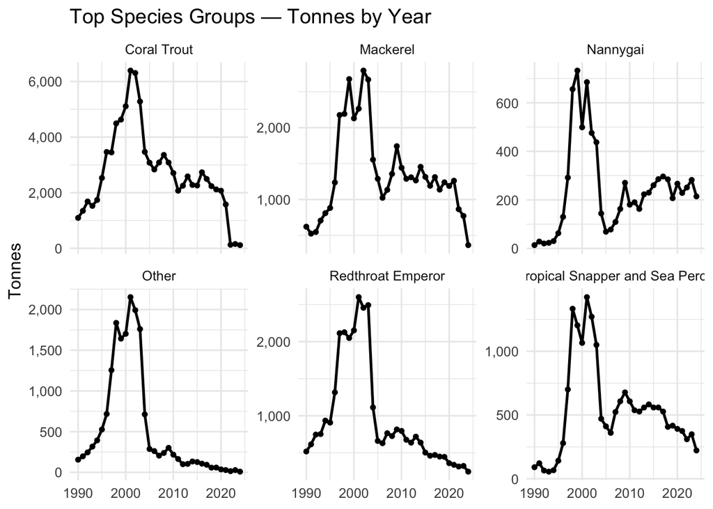

```r
top_groups <- tidy %>%
  filter(Metric == "Tonnes") %>%
  group_by(SpeciesGroup) %>%
  summarise(TotalTonnes = sum(Value, na.rm = TRUE), .groups = "drop") %>%
  slice_max(TotalTonnes, n = 6) %>%
  pull(SpeciesGroup)

top_tonnes <- tidy %>%
  filter(Metric == "Tonnes", SpeciesGroup %in% top_groups) %>%
  group_by(Year, SpeciesGroup) %>%
  summarise(Tonnes = sum(Value, na.rm = TRUE), .groups = "drop")

p_top <- ggplot(top_tonnes, aes(Year, Tonnes)) +
  geom_line(linewidth = 0.9) +
  geom_point(size = 1.3) +
  scale_y_continuous(labels = label_number(big.mark = ",")) +
  facet_wrap(~ SpeciesGroup, scales = "free_y", ncol = 3) +
  labs(title = "Top Species Groups — Tonnes by Year",
       y = "Tonnes",
       x = NULL)

p_top
```

```r
ggsave(file.path(plots_dir, "top_speciesgroups_tonnes_by_year.png"), p_top, width = 10, height = 7, dpi = 300)
```

Figure 2. Top six species groups by total catch (tonnes). Each panel shows annual tonnage for one group (free y-axis per panel for readability). Dominant groups (e.g., coral trout/mackerel, depending on your data) contribute most of the catch and exhibit distinct peaks and troughs across years. Interpret panel scales carefully when comparing magnitudes. Source: QFISH Commercial Line Fishery.

## Regional view

we are suming Tonnes by region to see the spatial differences.

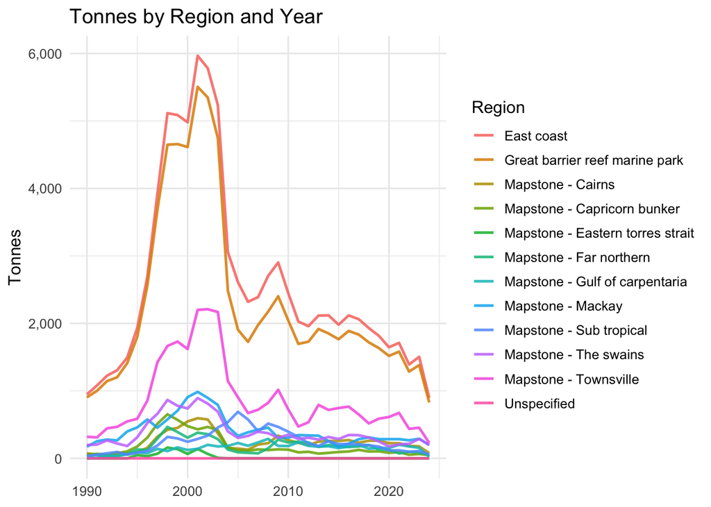

```r
regional <- tidy %>%
  filter(Metric == "Tonnes") %>%
  group_by(Region, Year) %>%
  summarise(Tonnes = sum(Value, na.rm = TRUE), .groups = "drop")

p_reg <- ggplot(regional, aes(Year, Tonnes, colour = Region)) +
  geom_line(linewidth = 0.9, alpha = 0.85) +
  scale_y_continuous(labels = label_number(big.mark = ",")) +
  labs(title = "Tonnes by Region and Year",
       y = "Tonnes",
       x = NULL,
       colour = "Region")

p_reg
```

```r
ggsave(file.path(plots_dir, "region_tonnes_by_year.png"), p_reg, width = 10, height = 6, dpi = 300)
```

Figure 3. Catch (tonnes) by region and year. Lines show total yearly catch per region (summed across species). Regions differ in both magnitude and trend—offshore/GBR regions typically contribute the largest volumes, while some inshore regions are smaller or more stable through time. Source: QFISH Commercial Line Fishery.